# Testing Youtube API Query and Document Matrices

Loading Libraries

```r
set.seed(1234)
library(dplyr)
library(tuber)
library(tm)
library(tidyverse)
```

```r
library(wordcloud)
library(RColorBrewer)
```

Connecting to Youtube API

```r
api_key <- "AIzaSyB-t-2C_R7oxYKZHRGmPVuUDh1mABjX5B4"
client_id <- "948879317402-mmlrs047ea59ebead9o1fk27sdd8h8li.apps.googleusercontent.com"
client_secret <- "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"
yt_oauth(client_id,client_secret)
```

Pull Data from Nikocado Avocado Mukbang Youtube Channel. Selected relevant data columns for visualization. Converted the character variable: ‘publication date’ into a date variable to derive total days since video was posted. Removed weird • character that nikocado likes to put in alot of his video titles for some reason

```r
chstat <- get_all_channel_video_stats(channel_id = "UCDwzLWgGft47xQ30u-vjsrg")
nikodata <- subset(chstat,select=-c(id,favoriteCount,commentCount,url,channel_id,channel_title))

nikodata$publication_date <- substr(nikodata$publication_date,1,10)
nikodata <- nikodata %>%
  mutate(publication_date = as.Date(publication_date, "%Y-%m-%d"))%>%
  mutate(NumberOfDays = as.numeric(Sys.Date() - publication_date))

nikodata$title <- gsub("•"," ", nikodata$title)
```

Creating a Word Cloud of most used words. Turn title columns into a corpus. Removed punctuation, numbers and common stopwords from corpus

```r
nikotitle <- nikodata$title
nikocorpus <- Corpus(VectorSource(nikotitle))
#inspect(nikocorpus)

nikocorpus <- tm_map(nikocorpus, removePunctuation)
nikocorpus <- tm_map(nikocorpus, content_transformer(removeWords), stopwords("english"))
nikocorpus <- tm_map(nikocorpus, removeNumbers)
```

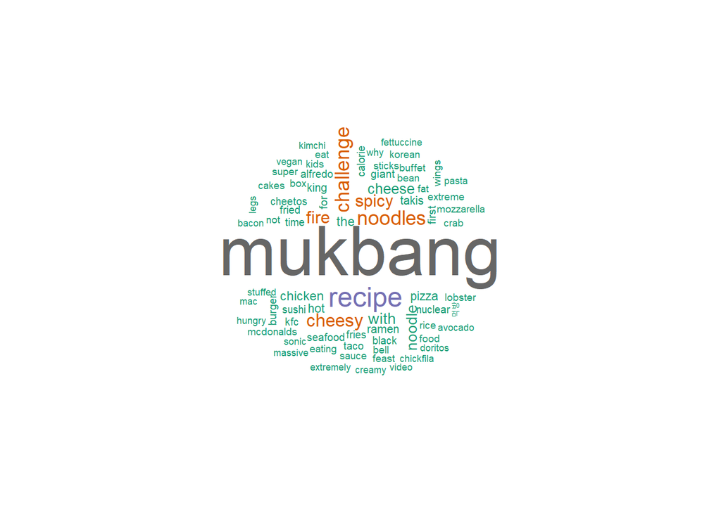

```r
wordcloud(nikocorpus, max.words=75, random.order=FALSE,            colors=brewer.pal(12, "Dark2"))
```

Identifying effect of words on total views Keeping top 100 terms

```r
nikodtm <- DocumentTermMatrix(nikocorpus)
nikodtms <- removeSparseTerms(nikodtm, .995)

nikomatrix<-as.matrix(nikodtms)
word.freq <-colSums(nikomatrix)
word.freq <-sort(word.freq,decreasing=T)

word.freq[1:10]
```

```
##   mukbang    recipe   noodles challenge    cheesy     spicy      fire      with
##       585       181       112       108        93        84        83        67
##    noodle    cheese
##        62        58
```

```r
corr <- cor(as.numeric(nikodata$viewCount), nikomatrix)
corr <- abs(corr)

top100 = order(corr, decreasing=T)[1:100]
top100words = colnames(corr)[top100]
top100words
```

```
##   [1] "chick"        "hungry"       "fat"          "fire"         "extreme"
##   [6] "the"          "noodles"      "mukbang"      "spicy"        "heart"
##  [11] "attack"       "grill"        "cakes"        "with"         "takis"
##  [16] "made"         "recipe"       "ever"         "best"         "rice"
##  [21] "camera"       "matt"         "stonies"      "mala"         "ive"
##  [26] "fuego"        "extremely"    "kids"         "together"     "떡볶이"
##  [31] "challenge"    "cheesy"       "volcano"      "worlds"       "eating"
##  [36] "food"         "pepper"       "choi"         "zach"         "video"
##  [41] "break"        "pizza"        "chicken"      "calorie"      "pasta"
##  [46] "fries"        "super"        "sticks"       "noodle"       "not"
##  [51] "street"       "ramen"        "feast"        "avocado"      "flamin"
##  [56] "mozzarella"   "for"          "thai"         "loaded"       "our"
##  [61] "christmas"    "wings"        "bacon"        "먹방" "짜장면"
##  [66] "fried"        "calories"     "drunk"        "years"        "burrito"
##  [71] "show"         "jajangmyeon"  "donuts"       "cheese"       "quesadilla"
##  [76] "roll"         "butter"       "dogs"         "cheeseburger" "cheesecake"
##  [81] "breakfast"    "cake"         "crispy"       "chips"        "innout"
##  [86] "five"         "guys"         "giant"        "bloves"       "dumplings"
##  [91] "chickfila"    "time"         "why"          "lobster"      "las"
##  [96] "vegas"        "cheetos"      "entire"       "durian"       "first"
```

```r
nikocombineddf = as.data.frame(cbind(viewcount = as.numeric(nikodata$viewCount), nikomatrix))
```

Stepwise Regression for first 50 terms, and terms of interest. Subjectively selected

```r
#Result of stepwise model with 50 most used terms
nikomodel = lm(viewcount~chick + fire + extreme + noodles + mukbang + spicy + heart + cakes + takis, data=nikocombineddf)
summary(nikomodel)
```

```
##
## Call:
## lm(formula = viewcount ~ chick + fire + extreme + noodles + mukbang +
##     spicy + heart + cakes + takis, data = nikocombineddf)
##
## Residuals:
##      Min       1Q   Median       3Q      Max
## -3688395  -480704  -272202   115524 20788801
##
## Coefficients:
##             Estimate Std. Error t value Pr(>|t|)
## (Intercept)  1423463     145341   9.794  < 2e-16 ***
## chick        2911063     514211   5.661 2.23e-08 ***
## fire          535988     197877   2.709 0.006928 **
## extreme       792568     404852   1.958 0.050684 .
## noodles       317960     154919   2.052 0.040517 *
## mukbang      -855870     157425  -5.437 7.61e-08 ***
## spicy         270398     191135   1.415 0.157623
## heart        1689382     667920   2.529 0.011657 *
## cakes        1435275     420346   3.415 0.000678 ***
## takis         648886     267380   2.427 0.015495 *
## ---
## Signif. codes:  0 '***' 0.001 '**' 0.01 '*' 0.05 '.' 0.1 ' ' 1
##
## Residual standard error: 1415000 on 669 degrees of freedom
## Multiple R-squared:  0.1988, Adjusted R-squared:  0.188
## F-statistic: 18.44 on 9 and 669 DF,  p-value: < 2.2e-16
```

In addition, many terms are only mentioned once or rarely, which affects the probability of the term being significant when included in the model.

A new model of only food terms could be used instead to visualize the effect on total views, but the standard error may be too high due to lack of samples + it does not account for natural growth of a channel.